# Visualisation tools

[figure not shown]

Data visualisation helps to tell stories by curating and transforming data into a form that is easier to understand and engage with, removing the noise and highlighting useful information. In this notebook we will explore some of the ways you can visualise and represent your data including exploring the different code libraries in EASI, visualisation strategies and their use cases.

References:

- 3 - Data and visualisation python libraries
- https://datashader.org/getting_started/Pipeline.html
- https://towardsdatascience.com/an-incomplete-guide-to-accessible-data-visualization-33f15bfcc400
- https://www.highcharts.com/blog/tutorials/10-guidelines-for-dataviz-accessibility/
- https://it.wisc.edu/learn/make-it-accessible/accessible-data-visualizations/

### Selection of python visualisation libraries available in EASI

- Plotly
- Folium
- Seaborn

## Imports

```python
# Common imports and settings
import os, sys
os.environ['USE_PYGEOS'] = '0'
from IPython.display import Markdown
import pandas as pd
pd.set_option("display.max_rows", None)
import xarray as xr

# Datacube
import datacube
from datacube.utils.rio import configure_s3_access
import odc.geo.xr                                  # https://github.com/opendatacube/odc-geo
from datacube.utils import masking  # https://github.com/opendatacube/datacube-core/blob/develop/datacube/utils/masking.py
from odc.algo import enum_to_bool                  # https://github.com/opendatacube/odc-tools/blob/develop/libs/algo/odc/algo/_masking.py
from dea_tools.plotting import display_map, rgb    # https://github.com/GeoscienceAustralia/dea-notebooks/tree/develop/Tools

# Dask
from dask.distributed import Client, LocalCluster

# EASI defaults
import git
repo = git.Repo('.', search_parent_directories=True)
if repo.working_tree_dir not in sys.path: sys.path.append(repo.working_tree_dir)
from easi_tools import EasiDefaults
from easi_tools.notebook_utils import mostcommon_crs, initialize_dask, localcluster_dashboard, heading
from easi_tools.load_s2l2a import load_s2l2a_with_offset
```

```python
# EASI defaults
easi = EasiDefaults()

family = 'sentinel-2'
product = easi.product(family)
display(Markdown(f'Default {family} product for "{easi.name}": [{product}]({easi.explorer}/products/{product})'))
```

```
Successfully found configuration for deployment "csiro"
```

Default sentinel-2 product for "csiro": ga_s2am_ard_3

```python
# Local cluster
cluster = LocalCluster(n_workers=2, threads_per_worker=4)
client = Client(cluster)
display(client)

dashboard_address = localcluster_dashboard(client=client,server=easi.hub)
display(f'Dashboard: {dashboard_address}')
```

Client

Client-70874acc-2ec6-11ef-85c2-063fee4c917c

| **Connection method:** Cluster object | **Cluster type:** distributed.LocalCluster |
| --- | --- |
| **Dashboard:** http://127.0.0.1:37933/status |  |

**Cluster Info**

LocalCluster

f64da587

| **Dashboard:** http://127.0.0.1:37933/status | **Workers:** 2 |
| --- | --- |
| **Total threads:** 8 | **Total memory:** 124.00 GiB |
| **Status:** running | **Using processes:** True |

**Scheduler Info**

Scheduler

Scheduler-b8b4fbff-8afe-4fd5-b97a-4a0402ff76e2

| **Comm:** tcp://127.0.0.1:44069 | **Workers:** 2 |
| --- | --- |
| **Dashboard:** http://127.0.0.1:37933/status | **Total threads:** 8 |
| **Started:** Just now | **Total memory:** 124.00 GiB |

**Workers**

**Worker: 0**

| **Comm:** tcp://127.0.0.1:44339 | **Total threads:** 4 |
| --- | --- |
| **Dashboard:** http://127.0.0.1:46769/status | **Memory:** 62.00 GiB |
| **Nanny:** tcp://127.0.0.1:39223 |  |
| **Local directory:** /tmp/dask-scratch-space/worker-wwlnc17a |  |

**Worker: 1**

| **Comm:** tcp://127.0.0.1:40615 | **Total threads:** 4 |
| --- | --- |
| **Dashboard:** http://127.0.0.1:36317/status | **Memory:** 62.00 GiB |
| **Nanny:** tcp://127.0.0.1:43677 |  |
| **Local directory:** /tmp/dask-scratch-space/worker-3gwgw0g2 |  |

```
'Dashboard: https://hub.csiro.easi-eo.solutions/user/csiro-csiro-aad_pag064@csiro.au/proxy/37933/status'
```

### Example data

```python
# Datacube (Xarray)
dc = datacube.Datacube()
configure_s3_access(aws_unsigned=False, requester_pays=True, client=client);

# Default area of interest
display(Markdown(f'#### Location: {easi.location}'))
display(Markdown(f'See: {easi.explorer}/products/{product}'))

latitude_range = easi.latitude
longitude_range = easi.longitude
time_range = easi.time
# Or set your own latitude / longitude
# latitude_range = (21.5, 23.5)
# longitude_range = (88, 90.8)
# time_range = ('2022-01-01', '2022-03-01')

query = {
    'product': product,       # Product name
    'x': longitude_range,     # "x" axis bounds
    'y': latitude_range,      # "y" axis bounds
    'time': time_range,       # Any parsable date strings
}

# Most common CRS
native_crs = mostcommon_crs(dc, query)
print(f'Most common native CRS: {native_crs}')

# Measurement aliases
alias = easi.aliases(family)
measurements = [alias[x] for x in ['blue', 'red', 'green', 'nir', 'scl']]

# Target xarray parameters
load_params = {
    'measurements': measurements,  # Selected measurement or alias names
    'output_crs': native_crs,                       # Target EPSG code
    'resolution': (-20, 20),                        # Target resolution
    'group_by': 'solar_day',                        # Scene grouping
    'dask_chunks': {'x': 2048, 'y': 2048},          # Dask chunks
}

# Load data
xr_data = dc.load(**(query | load_params))

# Mask and scale (not yet generic across EASIs)
# measurement_info = dc.list_measurements().loc[query['product']]
# for vv in xr_data.data_vars:
#     scale = measurement_info.loc[vv,'scale_factor']
#     offset = measurement_info.loc[vv,'add_offset']
#     if not pd.isnull(scale) and not pd.isnull(offset):
#         xr_data[vv] = xr_data[vv] * scale + offset

# Calculate with .persist()
# TODO

display(xr_data)
```

Location: Lake Hume, Australia

See: https://explorer.csiro.easi-eo.solutions/products/ga_s2am_ard_3

```
Most common native CRS: epsg:32755
```

```
<xarray.Dataset> Size: 339MB
Dimensions:      (time: 6, y: 2775, x: 2260)
Coordinates:
  * time         (time) datetime64[ns] 48B 2020-02-02T00:16:38.160910 ... 202...
  * y            (y) float64 22kB 6.038e+06 6.038e+06 ... 5.983e+06 5.983e+06
  * x            (x) float64 18kB 4.819e+05 4.82e+05 ... 5.271e+05 5.271e+05
    spatial_ref  int32 4B 32755
Data variables:
    blue         (time, y, x) int16 75MB dask.array<chunksize=(1, 2048, 2048), meta=np.ndarray>
    red          (time, y, x) int16 75MB dask.array<chunksize=(1, 2048, 2048), meta=np.ndarray>
    green        (time, y, x) int16 75MB dask.array<chunksize=(1, 2048, 2048), meta=np.ndarray>
    nbart_nir_1  (time, y, x) int16 75MB dask.array<chunksize=(1, 2048, 2048), meta=np.ndarray>
    oa_fmask     (time, y, x) uint8 38MB dask.array<chunksize=(1, 2048, 2048), meta=np.ndarray>
Attributes:
    crs:           epsg:32755
    grid_mapping:  spatial_ref
```

```python
# Geojson (Pandas)
```

```python
# Web data (WMS/WCS)
```

## Matplotlib

Further information

- https://docs.xarray.dev/en/latest/user-guide/plotting.html

```python
%matplotlib inline
import matplotlib.pyplot as plt
```

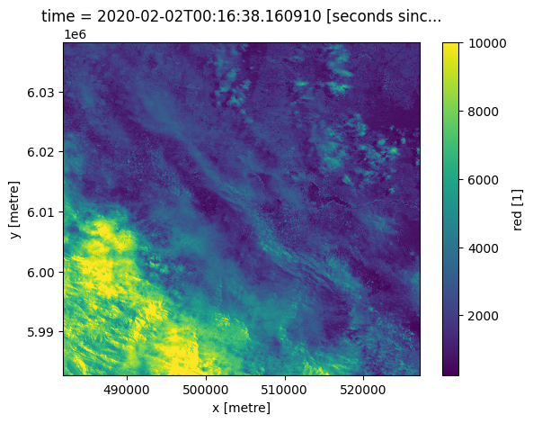

```python
# Basic plot
# - The default 'backend' for xarray.plot is 'matplotlib'

# Select a 2D xarray grid for matplotlib
# - Xarray will label axes and title if it can
xr_data.red.isel(time=0).plot()   # The red band, first time slice, default colourbar for the data range
```

```
<xarray.plot.facetgrid.FacetGrid at 0x7f75a94bc640>
```

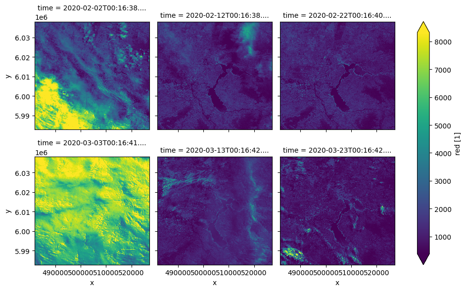

```python
# Subplots

# The red band, all time slices one per subplot, default colourbar for the data range
# The robust selects a colour range applicable to all subplots)
xr_data.red.plot(col="time", col_wrap=3, robust=True)
```

### Setting options

#### Color options

Pre-configured colorbars are described at https://matplotlib.org/stable/users/explain/colors/colormaps.html. It is also possible to create your own.

See also the Colorcet library in the holoviews stack for additional colorbar definitions.

For human considerations of colour options see https://colorbrewer2.org/

#### Figure options

Matplotlib provides tools to access and manipulate most low-level fetures of a plot such as the axes, labels and overlays. Typically this requires getting a *handle* to the figure object and the axis objects. For example `fig, ax = subplots(...)`.

#### Generic options

Plot options can also be customised for a matplotlib session, see https://matplotlib.org/stable/users/explain/customizing.html

```python
# Export
```

## Hvplot

- Hvplot
- Holoviews
- Datashader

```python
# Holoviews, Datashader and Bokeh
import hvplot.pandas
import hvplot.xarray
import panel as pn
import colorcet as cc
import cartopy.crs as ccrs
from datashader import reductions
from holoviews import opts
# hv.extension('bokeh', logo=False)
```

```python
# Basic plot
```

```python
# Groups
```

```python
# Setting options
```

```python
# Export
```

## Interactive plots

- Panel
- Plotly
- Bokeh

```python
# Example: Hvplot and Panel
```

## Dashboards

To prototype a data driven web site and user interface.

- Streamlit